# Ball Horticultural Coding Challenge

Download/Import dependencies if needed

```r
install.packages("gplots")
library(gplots)
```

First of all, I will import the data file and do a little bit of EDA to dive into the data and see what I’m working with. I will assume here that 3 replicates were taken, baseline expression for each gene was measured, the bud was then given a treatment, and then the change in expression of each gene was measured.

```r
exprs.data <- read.delim("test_gene_expression_matrix.txt", header = TRUE, sep = "\t")
print(head(exprs.data))
```

|  | Name | Bud_Rep1 | Bud_Rep2 | Bud_Rep3 | Day2_Rep1 | Day2_Rep2 | Day2_Rep3 |
| --- | --- | --- | --- | --- | --- | --- | --- |
| 1 | Flower_060945-RA | 10.83150 | 9.56753 | 6.24958 | 9.60078 | 6.01394 | 5.99760 |
| 2 | Flower_027927-RA | 0.00000 | 0.00000 | 0.00000 | 0.00000 | 0.00000 | 0.00000 |
| 3 | Flower_027924-RA | 1.56159 | 2.00614 | 1.85567 | 2.57317 | 1.27196 | 1.32492 |
| 4 | Flower_027916-RA | 8.00183 | 7.34657 | 6.13769 | 29.93260 | 29.57190 | 29.14260 |
| 5 | Flower_027915-RA | 0.00000 | 0.00000 | 0.00000 | 2.47182 | 1.11015 | 0.00000 |
| 6 | Flower_027910-RA | 0.00000 | 0.00000 | 0.00000 | 0.00000 | 0.00000 | 0.00000 |

```r
#confirm that all genes are present only once
#looks like there are ~29k instances of genes with no repeats
cat("Number of unique genes:", length(unique(exprs.data$Name)))
```

```
Number of unique genes: 29333
```

```r
cat("\nNumber of rows:", length(exprs.data$Name), "\n")
```

```
Number of rows: 29333
```

```r
#find the most highly expressed gene for each of the samples tested, these seem to be Flower_024636 and Flower_010909-RA for the untreated group, and Flower_011193-RA for the treated group
#original replicates:
cat("\n","Maximum expression of original replicates:","\n")
```

```
 Maximum expression of original replicates:
```

```r
cat(as.character(exprs.data$Name[which.max(exprs.data$Bud_Rep1)]), max(exprs.data$Bud_Rep1), "\n")
```

```
Flower_024636-RA 25513.5
```

```r
cat(as.character(exprs.data$Name[which.max(exprs.data$Bud_Rep2)]), max(exprs.data$Bud_Rep2), "\n")
```

```
Flower_010909-RA 25231
```

```r
cat(as.character(exprs.data$Name[which.max(exprs.data$Bud_Rep3)]), max(exprs.data$Bud_Rep3), "\n")
```

```
Flower_024636-RA 24956.2
```

```r
#treated replicates:
cat("\n","Maximum expression of treated replicates:","\n")
```

```
 Maximum expression of treated replicates:
```

```r
cat(as.character(exprs.data$Name[which.max(exprs.data$Day2_Rep1)]), max(exprs.data$Day2_Rep1), "\n")
```

```
Flower_011193-RA 13699.7
```

```r
cat(as.character(exprs.data$Name[which.max(exprs.data$Day2_Rep2)]), max(exprs.data$Day2_Rep2), "\n")
```

```
Flower_011193-RA 14201.6
```

```r
cat(as.character(exprs.data$Name[which.max(exprs.data$Day2_Rep3)]), max(exprs.data$Day2_Rep3), "\n")
```

```
Flower_011193-RA 13860.4
```

```r
#find the average expression of all genes for each replicate and standard deviation
#I don't think that this information would be particularly useful, but I was curious anyway. It looks like the average expression tends to be around 34
#original replicates:
cat("\n","Mean expression of original replicates:","\n")
```

```
 Mean expression of original replicates:
```

```r
cat(mean(exprs.data$Bud_Rep1), sd(exprs.data$Bud_Rep1), "\n")
```

```
34.09129 267.6051
```

```r
cat(mean(exprs.data$Bud_Rep2), sd(exprs.data$Bud_Rep2), "\n")
```

```
34.09129 257.1643
```

```r
cat(mean(exprs.data$Bud_Rep3), sd(exprs.data$Bud_Rep3), "\n")
```

```
34.0913 264.1423
```

```r
#treated replicates:
cat("\n","Mean expression of treated replicates:","\n")
```

```
 Mean expression of treated replicates:
```

```r
cat(mean(exprs.data$Day2_Rep1), sd(exprs.data$Bud_Rep1), "\n")
```

```
34.09129 267.6051
```

```r
cat(mean(exprs.data$Day2_Rep2), sd(exprs.data$Bud_Rep2), "\n")
```

```
34.0913 257.1643
```

```r
cat(mean(exprs.data$Day2_Rep3), sd(exprs.data$Bud_Rep3), "\n")
```

```
34.0913 264.1423
```

```r
#Finally, I thought it may be nice to see how many genes are expressed in each sample. In other words, how many genes are nonzero.
#original
cat("\n","Total number of genes expressed in original replicates, proportion expressed","\n")
```

```
 Total number of genes expressed in original replicates, proportion expressed
```

```r
cat(length(which(exprs.data$Bud_Rep1 > 0)), length(which(exprs.data$Bud_Rep1 > 0))/29333,"\n")
```

```
20568 0.7011898
```

```r
cat(length(which(exprs.data$Bud_Rep2 > 0)), length(which(exprs.data$Bud_Rep2 > 0))/29333,"\n")
```

```
20608 0.7025534
```

```r
cat(length(which(exprs.data$Bud_Rep3 > 0)), length(which(exprs.data$Bud_Rep3 > 0))/29333,"\n")
```

```
20841 0.7104967
```

```r
#treated
cat("\n","Total number of genes expressed in original replicates, proportion expressed","\n")
```

```
 Total number of genes expressed in original replicates, proportion expressed
```

```r
cat(length(which(exprs.data$Day2_Rep1 > 0)), length(which(exprs.data$Day2_Rep1 > 0))/29333,"\n")
```

```
20471 0.6978829
```

```r
cat(length(which(exprs.data$Day2_Rep2 > 0)), length(which(exprs.data$Day2_Rep2 > 0))/29333,"\n")
```

```
20747 0.7072921
```

```r
cat(length(which(exprs.data$Day2_Rep3 > 0)), length(which(exprs.data$Day2_Rep3 > 0))/29333,"\n")
```

```
20191 0.6883374
```

In a data analysis project I think it is important to establish the question to be answered, and define a minimum viable product that should be able to be presented and/or submitted.

In this case I defined the question to be: Does the treatment result in any observable differences in gene expression over the 3 replicates between the original and Day2 treatments?

My MVP would be (as described in the instructions): How many genes in each replicate are differentially expressed after the treatment?

Additionally, I would plan to include some sort of heatmap in order to clearly communicate the change in gene expression to all parties involved. I would use the top 10 (20?) most differentially expressed genes that we found using this treatment based on 3 replicates in order to condense the data into something that is easily visualized.

For the actual analysis, I will first create additional columns to represent the change in expression in each gene over the 3 replicates, and then find the number of differentially expressed genes. I decided to start off with looking at genes in which the difference in expression was greater than 0.

```r
exprs.data$Delta_Rep1 <- exprs.data$Day2_Rep1-exprs.data$Bud_Rep1
exprs.data$Delta_Rep2 <- exprs.data$Day2_Rep2-exprs.data$Bud_Rep2
exprs.data$Delta_Rep3 <- exprs.data$Day2_Rep3-exprs.data$Bud_Rep3

#also another column for the average change across 3 replicates
for (i in 1:nrow(exprs.data)){
  exprs.data$Delta_Ave[i] = sum(exprs.data$Day2_Rep1[i], exprs.data$Day2_Rep2[i], exprs.data$Day2_Rep3[i])/3 - sum(exprs.data$Bud_Rep1[i], exprs.data$Bud_Rep2[i], exprs.data$Bud_Rep3[i])/3
}

#How many genes per replicate show ANY change in expression between the starting and day2 values?
#rep1
print("Number of genes differentially expressed in Rep1:")
```

```
[1] "Number of genes differentially expressed in Rep1:"
```

```r
length(which(abs(exprs.data$Delta_Rep1) > 0))
```

```
[1] 21923
```

```r
#rep2
print("Number of genes differentially expressed in Rep2:")
```

```
[1] "Number of genes differentially expressed in Rep2:"
```

```r
length(which(abs(exprs.data$Delta_Rep2) > 0))
```

```
[1] 22019
```

```r
#rep3
print("Number of genes differentially expressed in Rep3:")
```

```
[1] "Number of genes differentially expressed in Rep3:"
```

```r
length(which(abs(exprs.data$Delta_Rep3) > 0))
```

```
[1] 21825
```

This analysis shows that ~20,000 genes are differentially expressed. This is a lot to consider, and I would assume that part of this difference in expression should be written off as natural biological variance and/or background noise. Now I will attempt to use additional methods in order to quantify the most highly differential genes.

Finding the “top 10” upregulated and downregulated genes for each replicate:

```r
#Return the top and bottom 10 genes from each replicate:
#rep1
cat("Rep 1 Top 10 upregulated genes:","\n")
```

```
Rep 1 Top 10 upregulated genes:
```

```r
#indicies of top 10 genes
ind.rep1.up <- head(order(-exprs.data$Delta_Rep1), 10)
up.rep1 <- exprs.data$Name[ind.rep1.up]
print(as.character(up.rep1))
```

```
 [1] "Flower_006273-RA" "Flower_011193-RA" "Flower_009921-RA" "Flower_031266-RA" "Flower_018827-RA" "Flower_025536-RA" "Flower_026661-RA"
 [8] "Flower_043514-RA" "Flower_050923-RA" "Flower_009868-RA"
```

```r
up.rep1.val <- exprs.data$Delta_Rep1[ind.rep1.up]
print(up.rep1.val)
```

```
 [1] 11536.560 11137.180  8087.890  7281.608  7032.393  6763.005  5257.145  4969.250  4736.668  4733.750
```

```r
cat("Rep 1 Top 10 downregulated genes:","\n")
```

```
Rep 1 Top 10 downregulated genes:
```

```r
ind.rep1.down <- head(order(exprs.data$Delta_Rep1), 10)
down.rep1 <- exprs.data$Name[ind.rep1.down]
print(as.character(down.rep1))
```

```
 [1] "Flower_024636-RA" "Flower_010909-RA" "Flower_031552-RA" "Flower_017257-RA" "Flower_043208-RA" "Flower_045575-RA" "Flower_018549-RA"
 [8] "Flower_049027-RA" "Flower_031553-RA" "Flower_010394-RA"
```

```r
down.rep1.val <- exprs.data$Delta_Rep1[ind.rep1.down]
print(down.rep1.val)
```

```
 [1] -25336.149 -22713.130 -10695.414  -6213.420  -5406.990  -5161.531  -4341.036  -3601.270  -3301.300  -3144.213
```

```r
#rep2
cat("Rep 2 Top 10 upregulated genes:","\n")
```

```
Rep 2 Top 10 upregulated genes:
```

```r
ind.rep2.up <- head(order(-exprs.data$Delta_Rep2), 10)
up.rep2 <- exprs.data$Name[ind.rep2.up]
print(as.character(up.rep2))
```

```
 [1] "Flower_011193-RA" "Flower_006273-RA" "Flower_031266-RA" "Flower_009921-RA" "Flower_026661-RA" "Flower_025536-RA" "Flower_018827-RA"
 [8] "Flower_050923-RA" "Flower_034139-RA" "Flower_058304-RA"
```

```r
up.rep2.val <- exprs.data$Delta_Rep2[ind.rep2.up]
print(up.rep2.val)
```

```
 [1] 11947.620 10221.260  6408.344  6029.080  5288.170  4650.257  4522.782  4364.585  3621.240  3536.920
```

```r
cat("Rep 2 Top 10 downregulated genes:","\n")
```

```
Rep 2 Top 10 downregulated genes:
```

```r
ind.rep2.down <- head(order(exprs.data$Delta_Rep2), 10)
down.rep2 <- exprs.data$Name[ind.rep2.down]
print(as.character(down.rep2))
```

```
 [1] "Flower_010909-RA" "Flower_024636-RA" "Flower_031552-RA" "Flower_017257-RA" "Flower_045575-RA" "Flower_043208-RA" "Flower_010394-RA"
 [8] "Flower_049027-RA" "Flower_018549-RA" "Flower_044314-RA"
```

```r
down.rep2.val <- exprs.data$Delta_Rep2[ind.rep2.down]
print(down.rep2.val)
```

```
 [1] -21668.510 -21546.441  -7196.020  -5053.700  -4557.677  -4528.990  -3716.231  -3694.470  -3512.353  -3313.530
```

```r
#rep3
cat("Rep 3 Top 10 upregulated genes:","\n")
```

```
Rep 3 Top 10 upregulated genes:
```

```r
ind.rep3.up <- head(order(-exprs.data$Delta_Rep3), 10)
up.rep3 <- exprs.data$Name[ind.rep3.up]
print(as.character(up.rep3))
```

```
 [1] "Flower_011193-RA" "Flower_006273-RA" "Flower_009921-RA" "Flower_031266-RA" "Flower_018827-RA" "Flower_025536-RA" "Flower_026661-RA"
 [8] "Flower_050923-RA" "Flower_029676-RA" "Flower_009868-RA"
```

```r
up.rep3.val <- exprs.data$Delta_Rep2[ind.rep3.up]
print(up.rep3.val)
```

```
 [1] 11947.620 10221.260  6029.080  6408.344  4522.782  4650.257  5288.170  4364.585  2896.840  3102.660
```

```r
cat("Rep 3 Top 10 downregulated genes:","\n")
```

```
Rep 3 Top 10 downregulated genes:
```

```r
ind.rep3.down <- head(order(exprs.data$Delta_Rep3), 10)
down.rep3 <- exprs.data$Name[ind.rep3.down]
print(as.character(down.rep3))
```

```
 [1] "Flower_024636-RA" "Flower_010909-RA" "Flower_031552-RA" "Flower_017257-RA" "Flower_043208-RA" "Flower_045575-RA" "Flower_018549-RA"
 [8] "Flower_030436-RA" "Flower_010394-RA" "Flower_049027-RA"
```

```r
down.rep3.val <- exprs.data$Delta_Rep2[ind.rep3.down]
print(down.rep3.val)
```

```
 [1] -21546.441 -21668.510  -7196.020  -5053.700  -4528.990  -4557.677  -3512.353  -2929.589  -3716.231  -3694.470
```

```r
#Overall
cat("Overall Top 10 upregulated genes:","\n")
```

```
Overall Top 10 upregulated genes:
```

```r
ind.ave.up <- head(order(-exprs.data$Delta_Ave), 10)
up.ave <- exprs.data$Name[ind.ave.up]
print(as.character(up.ave))
```

```
 [1] "Flower_011193-RA" "Flower_006273-RA" "Flower_009921-RA" "Flower_031266-RA" "Flower_018827-RA" "Flower_025536-RA" "Flower_026661-RA"
 [8] "Flower_050923-RA" "Flower_058304-RA" "Flower_010327-RA"
```

```r
up.ave.val <- exprs.data$Delta_Ave[ind.ave.up]
print(up.ave.val)
```

```
 [1] 11404.403 10789.367  7279.453  6653.405  5753.658  5600.467  5047.456  4460.225  3942.567  3933.636
```

```r
cat("Overall Top 10 downregulated genes:","\n")
```

```
Overall Top 10 downregulated genes:
```

```r
ind.ave.down <- head(order(exprs.data$Delta_Ave), 10)
down.ave <- exprs.data$Name[ind.ave.down]
print(as.character(down.ave))
```

```
 [1] "Flower_024636-RA" "Flower_010909-RA" "Flower_031552-RA" "Flower_017257-RA" "Flower_043208-RA" "Flower_045575-RA" "Flower_018549-RA"
 [8] "Flower_049027-RA" "Flower_010394-RA" "Flower_030436-RA"
```

```r
down.ave.val <- exprs.data$Delta_Ave[ind.ave.down]
print(down.ave.val)
```

```
 [1] -23903.471 -21650.257  -9045.530  -6270.627  -5456.570  -4616.953  -3950.322  -3582.517  -3496.142  -3330.000
```

Heatmaps

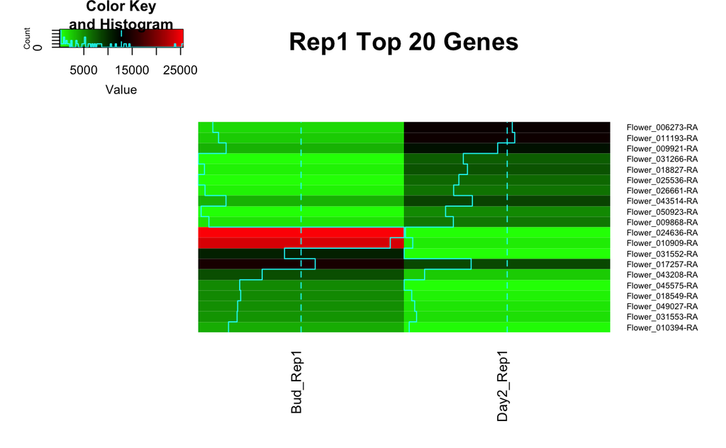

```r
#generate red to green color scheme
redgreen <- function(n) {
c(hsv(h=2/6, v=seq(1,0,length=n/2) ), hsv(h=0/6, v=seq(0,1,length=n/2)) )
}

#rep1
top20.rep1 <- c(ind.rep1.up, ind.rep1.down)
top20.rep1.heatmap <- data.matrix(exprs.data[top20.rep1, c("Bud_Rep1", "Day2_Rep1")])

heatmap.2(top20.rep1.heatmap, main = "Rep1 Top 20 Genes", labRow = exprs.data$Name[top20.rep1], dendrogram = "none", margins = c(7,7), cexCol = 1, cexRow = 0.6, Rowv = FALSE, Colv = FALSE, col = redgreen(100))
```

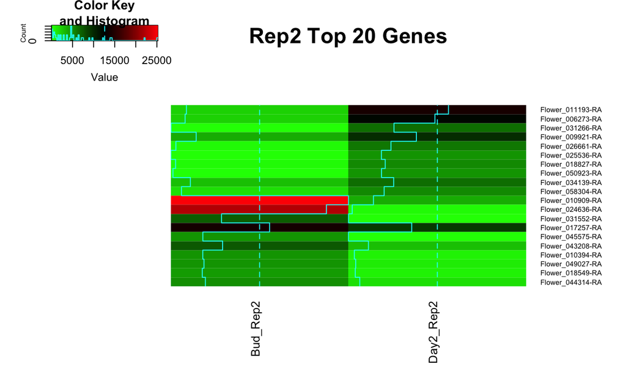

```r
#rep2
top20.rep2 <- c(ind.rep2.up, ind.rep2.down)
top20.rep2.heatmap <- data.matrix(exprs.data[top20.rep2, c("Bud_Rep2", "Day2_Rep2")])

heatmap.2(top20.rep2.heatmap, main = "Rep2 Top 20 Genes", labRow = exprs.data$Name[top20.rep2], dendrogram = "none", margins = c(7,7), cexCol = 1, cexRow = 0.6, Rowv = FALSE, Colv = FALSE, col = redgreen(100))
```

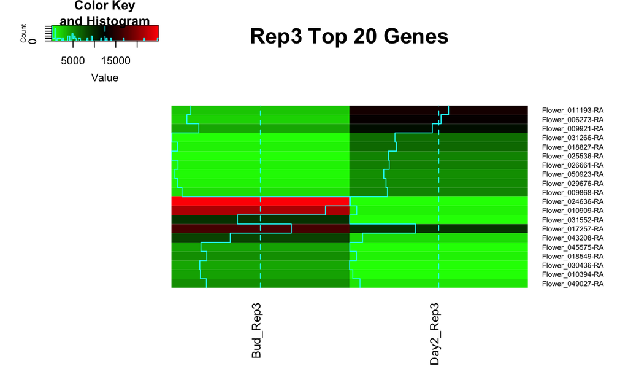

```r
#rep3
top20.rep3 <- c(ind.rep3.up, ind.rep3.down)
top20.rep3.heatmap <- data.matrix(exprs.data[top20.rep3, c("Bud_Rep3", "Day2_Rep3")])

heatmap.2(top20.rep3.heatmap, main = "Rep3 Top 20 Genes", labRow = exprs.data$Name[top20.rep3], dendrogram = "none", margins = c(7,7), cexCol = 1, cexRow = 0.6, Rowv = FALSE, Colv = FALSE, col = redgreen(100))
```

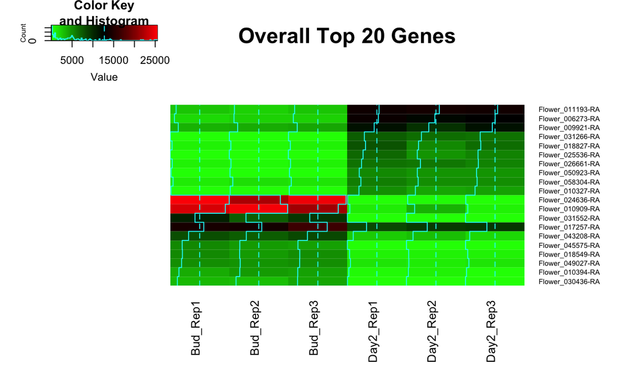

```r
#Overall
top20.ave <- c(ind.ave.up, ind.ave.down)
top20.ave.heatmap <- data.matrix(exprs.data[top20.ave, c("Bud_Rep1", "Bud_Rep2", "Bud_Rep3", "Day2_Rep1", "Day2_Rep2", "Day2_Rep3")])

heatmap.2(top20.ave.heatmap, main = "Overall Top 20 Genes", labRow = exprs.data$Name[top20.ave], dendrogram = "none", margins = c(7,7), cexCol = 1, cexRow = 0.6, Rowv = FALSE, Colv = FALSE, col = redgreen(100))
```

I experimented with taking the log of the expression values rather than raw values, to see if it created a clearer heatmap.

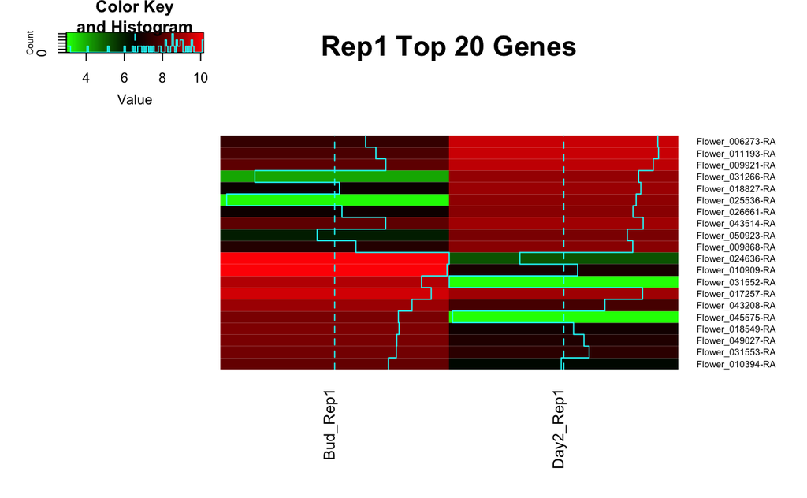

```r
#rep1
top20.rep1 <- c(ind.rep1.up, ind.rep1.down)
top20.rep1.heatmap <- data.matrix(log(exprs.data[top20.rep1, c("Bud_Rep1", "Day2_Rep1")]))

heatmap.2(top20.rep1.heatmap, main = "Rep1 Top 20 Genes", labRow = exprs.data$Name[top20.rep1], dendrogram = "none", margins = c(7,7), cexCol = 1, cexRow = 0.6, Rowv = FALSE, Colv = FALSE, col = redgreen(100))
```

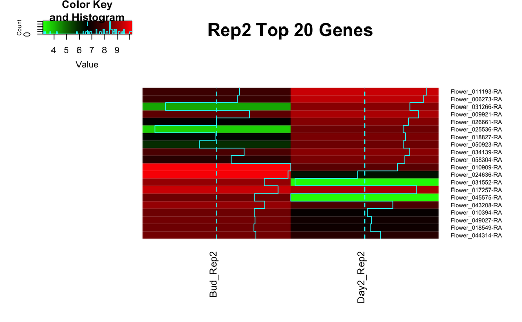

```r
#rep2
top20.rep2 <- c(ind.rep2.up, ind.rep2.down)
top20.rep2.heatmap <- data.matrix(log(exprs.data[top20.rep2, c("Bud_Rep2", "Day2_Rep2")]))

heatmap.2(top20.rep2.heatmap, main = "Rep2 Top 20 Genes", labRow = exprs.data$Name[top20.rep2], dendrogram = "none", margins = c(7,7), cexCol = 1, cexRow = 0.6, Rowv = FALSE, Colv = FALSE, col = redgreen(100))
```

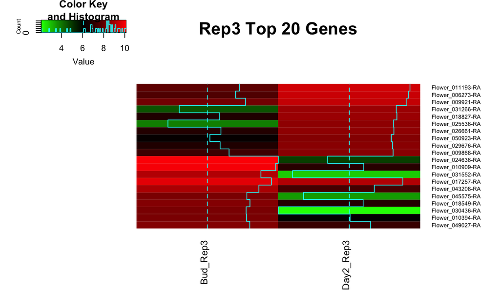

```r
#rep3
top20.rep3 <- c(ind.rep3.up, ind.rep3.down)
top20.rep3.heatmap <- data.matrix(log(exprs.data[top20.rep3, c("Bud_Rep3", "Day2_Rep3")]))

heatmap.2(top20.rep3.heatmap, main = "Rep3 Top 20 Genes", labRow = exprs.data$Name[top20.rep3], dendrogram = "none", margins = c(7,7), cexCol = 1, cexRow = 0.6, Rowv = FALSE, Colv = FALSE, col = redgreen(100))
```

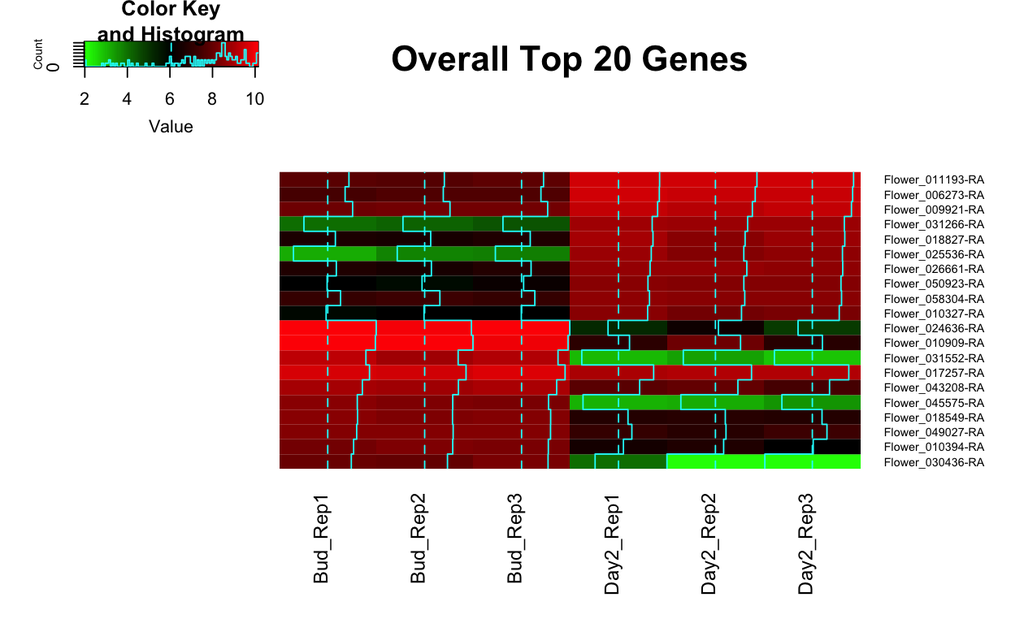

```r
#Overall
top20.ave <- c(ind.ave.up, ind.ave.down)
top20.ave.heatmap <- data.matrix(log(exprs.data[top20.ave, c("Bud_Rep1", "Bud_Rep2", "Bud_Rep3", "Day2_Rep1", "Day2_Rep2", "Day2_Rep3")]))

heatmap.2(top20.ave.heatmap, main = "Overall Top 20 Genes", labRow = exprs.data$Name[top20.ave], dendrogram = "none", margins = c(7,7), cexCol = 1, cexRow = 0.6, Rowv = FALSE, Colv = FALSE, col = redgreen(100))
```

Next, I wanted to allow the heatmap to create a dendrogram of genes, therefore clustering genes together that show a similar expression pattern between all samples. The thought behind this would be that it may be beneficial to look into highly variable genes that consistently show similar expression patterns between the Bud and Day2 treatments.

I decided to do this using a total of 50 genes (25 from both up- and down-regulated expression). I also decided to center and scale the expression values across the 6 samples in order to highlight the expression differences rather than the raw expression levels (as in the earlier heatmaps).

```r
#this also overwrites previously defined variables!!

#change heatmap to include top 25 instead of 10 and draw dendogram
cat("Overall Top 25 upregulated genes:","\n")
```

```
Overall Top 25 upregulated genes:
```

```r
ind.ave.up <- head(order(-exprs.data$Delta_Ave), 25)
up.ave <- exprs.data$Name[ind.ave.up]
print(as.character(up.ave))
```

```
 [1] "Flower_011193-RA" "Flower_006273-RA" "Flower_009921-RA" "Flower_031266-RA" "Flower_018827-RA" "Flower_025536-RA" "Flower_026661-RA"
 [8] "Flower_050923-RA" "Flower_058304-RA" "Flower_010327-RA" "Flower_009868-RA" "Flower_043514-RA" "Flower_002351-RA" "Flower_050776-RA"
[15] "Flower_034139-RA" "Flower_058395-RA" "Flower_025533-RA" "Flower_011249-RA" "Flower_029676-RA" "Flower_034138-RA" "Flower_047687-RA"
[22] "Flower_003029-RA" "Flower_058293-RA" "Flower_008444-RA" "Flower_023001-RA"
```

```r
up.ave.val <- exprs.data$Delta_Ave[ind.ave.up]
print(up.ave.val)
```

```
 [1] 11404.403 10789.367  7279.453  6653.405  5753.658  5600.467  5047.456  4460.225  3942.567  3933.636  3876.870  3562.007  3556.842
[14]  3360.727  3287.337  3224.547  3220.465  3099.547  3015.865  2819.247  2788.842  2769.444  2576.030  2571.138  2522.637
```

```r
cat("Overall Top 25 downregulated genes:","\n")
```

```
Overall Top 25 downregulated genes:
```

```r
ind.ave.down <- head(order(exprs.data$Delta_Ave), 25)
down.ave <- exprs.data$Name[ind.ave.down]
print(as.character(down.ave))
```

```
 [1] "Flower_024636-RA" "Flower_010909-RA" "Flower_031552-RA" "Flower_017257-RA" "Flower_043208-RA" "Flower_045575-RA" "Flower_018549-RA"
 [8] "Flower_049027-RA" "Flower_010394-RA" "Flower_030436-RA" "Flower_031553-RA" "Flower_044314-RA" "Flower_000999-RA" "Flower_033580-RA"
[15] "Flower_010629-RA" "Flower_031611-RA" "Flower_024637-RA" "Flower_000604-RA" "Flower_038916-RA" "Flower_037883-RA" "Flower_023812-RA"
[22] "Flower_008807-RA" "Flower_008764-RA" "Flower_019371-RA" "Flower_024328-RA"
```

```r
down.ave.val <- exprs.data$Delta_Ave[ind.ave.down]
print(down.ave.val)
```

```
 [1] -23903.471 -21650.257  -9045.530  -6270.627  -5456.570  -4616.953  -3950.322  -3582.517  -3496.142  -3330.000  -2992.787  -2922.813
[13]  -2711.909  -2305.316  -2165.922  -2116.952  -1781.494  -1685.928  -1672.693  -1608.194  -1537.632  -1478.310  -1368.196  -1303.042
[25]  -1250.471
```

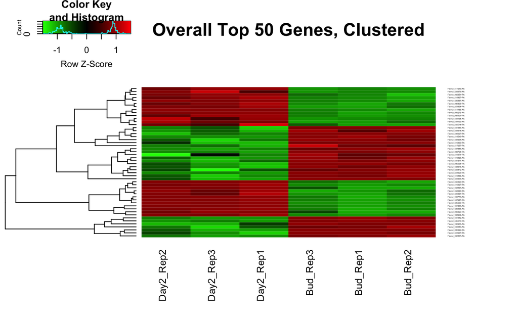

```r
top50.ave <- c(ind.ave.up, ind.ave.down)
top50.ave.heatmap <- data.matrix(log(exprs.data[top50.ave, c("Bud_Rep1", "Bud_Rep2", "Bud_Rep3", "Day2_Rep1", "Day2_Rep2", "Day2_Rep3")]))

heatmap.2(top50.ave.heatmap, main = "Overall Top 50 Genes, Clustered", labRow = exprs.data$Name[top50.ave], dendrogram = "row", margins = c(7,7), scale = "row", col = redgreen(100), cexCol = 1, cexRow = 0.2, trace = "none")
```